# 11. Intro to Machine Learning: Classification Technique

- Different Categories of Machine Learning Techniques
- Classification Techniques
- Case Study to explain Logistic Regression
- Building a classification Model
- Quality Metrics
- Visualization & Presentation

# 11.1 Different Categories of Machine Learning Techniques

[figure not shown]

This is a more exhaustive [review](https://towardsdatascience.com/types-of-machine-learning-algorithms-you-should-know-953a08248861)

**What is Machine Learning?**

Machine Learning is the ability for a computer to automatically learn and understand without being programmed time and again; using data ou feed in the data having different attributes or features that the algorithms have to understand and give you a decision boundary based on the data you provide it.

**What is a Model?**

Model is a mathematical representaion of a physical reality; A model is a generalized representation of casuality e.g. y = f(X) that holds generally correct and helps in simulating outcomes in real business situation

## 11.1.1 Types of Classification Techniques

- **Logistic Regression**
- Naive Bayes
- K-NN
- SVM
- Decision Trees

# 11.2 Case Study to prove the point

Same Case Study from Week 10

We will use a case study approach for the class to understand steps before building machine learning models to ensure the data is robust for making prodections.

This problem statement from an **online education platform** where we’ll look at factors that help us select the most promising leads, i.e. the leads that are most likely to convert into paying customers.

Our ultimate goal- We shall use the data from previous leads who did convert to a customer and many who did not to build a model that we can use to score incoming leads for preferential retargeting.

The data dictionary for the data set is [here](https://drive.google.com/file/d/11k24B6GNnurpFJobZwHomEGrYmjsWRsy/view?usp=sharing)

# 11.3 Load data and High level review

```python
import pandas as pd
import numpy as np
import matplotlib.pyplot as plt
import seaborn as sns
```

```python
df= pd.read_csv('https://raw.githubusercontent.com/sdhar-pycourse/py-datascience-biz/main/practise-datasets/Leads.csv', index_col=0)
```

```python
df.shape
```

```
(9240, 36)
```

```python
df.columns
```

```
Index(['Lead Number', 'Lead Origin', 'Lead Source', 'Do Not Email',
       'Do Not Call', 'Converted', 'TotalVisits',
       'Total Time Spent on Website', 'Page Views Per Visit', 'Last Activity',
       'Country', 'Specialization', 'How did you hear about X Education',
       'What is your current occupation',
       'What matters most to you in choosing a course', 'Search', 'Magazine',
       'Newspaper Article', 'X Education Forums', 'Newspaper',
       'Digital Advertisement', 'Through Recommendations',
       'Receive More Updates About Our Courses', 'Tags', 'Lead Quality',
       'Update me on Supply Chain Content', 'Get updates on DM Content',
       'Lead Profile', 'City', 'Asymmetrique Activity Index',
       'Asymmetrique Profile Index', 'Asymmetrique Activity Score',
       'Asymmetrique Profile Score',
       'I agree to pay the amount through cheque',
       'A free copy of Mastering The Interview', 'Last Notable Activity'],
      dtype='object')
```

```python
handle= ['prospsid', 'leadnum', 'origin', 'dne', 'dnc', 'target', 'totviz', 'tos', 'pageviz', 'lastact', 'country', 'splz',
         'leadsrc', 'curoccp', 'reason', 'srch', 'mag', 'newsart', 'edforum', 'newsad', 'digitalad', 'reco', 'updates', 'tag', 'leadquality', 'supchncont',
         'dmcontent', 'leadprofile', 'city', 'asymactidx', 'asymprofidx', 'asymactscr', 'asymprofscr', 'chkpay', 'freecp', 'lastnotact']
```

```python
column_map= dict(zip(df.columns, handle))
```

```python
df.rename(columns=column_map, inplace=True)
```

```python
df.columns
```

```
Index(['prospsid', 'leadnum', 'origin', 'dne', 'dnc', 'target', 'totviz',
       'tos', 'pageviz', 'lastact', 'country', 'splz', 'leadsrc', 'curoccp',
       'reason', 'srch', 'mag', 'newsart', 'edforum', 'newsad', 'digitalad',
       'reco', 'updates', 'tag', 'leadquality', 'supchncont', 'dmcontent',
       'leadprofile', 'city', 'asymactidx', 'asymprofidx', 'asymactscr',
       'asymprofscr', 'chkpay', 'freecp', 'lastnotact'],
      dtype='object')
```

## 10.2.1 Review Target Variable

We have no idea what kind of variable it is...

```python
df.target.isnull().sum()
```

```
0
```

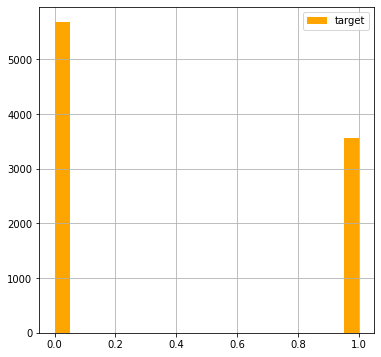

```python
df.target.hist(bins=20, figsize=(6,6), color= 'orange', legend=True)
```

# 11.4 Introducing Logistic Regression

- Logistic regression is a statistical method for predicting binary classes. The outcome or target variable is binary in nature. Binary means there are only two possible classes. For example, it can be used for cancer detection problems. It computes the probability of an event occurrence.
- Linear Regression Equation:
  - Where, y is dependent variable and x1, x2 ... and Xn are explanatory variables.

[figure not shown]

- Sigmoid Function:

[figure not shown]

- Apply Sigmoid function on linear regression:

[figure not shown]

Properties of Logistic Regression:

- The dependent variable in logistic regression is between 0 and 1; Follows a sigmoid function
- Estimation is done through maximum likelihood.

## 10.3.1 Sigmoid Function

[figure not shown]

# 11.5 Building a Logistic Regession Model

Several Steps needs to be followed for building a classification model

- Data Wrangling and cleaning from week 10
- Categorical variable treatment
  - Ordinal -> order integer mapping
  - Dummy Variable Creation
- Test Train Split
- Model Development using `sci-kit learn`

```python
df.columns
```

```
Index(['prospsid', 'leadnum', 'origin', 'dne', 'dnc', 'target', 'totviz',
       'tos', 'pageviz', 'lastact', 'country', 'splz', 'leadsrc', 'curoccp',
       'reason', 'srch', 'mag', 'newsart', 'edforum', 'newsad', 'digitalad',
       'reco', 'updates', 'tag', 'leadquality', 'supchncont', 'dmcontent',
       'leadprofile', 'city', 'asymactidx', 'asymprofidx', 'asymactscr',
       'asymprofscr', 'chkpay', 'freecp', 'lastnotact'],
      dtype='object')
```

## 11.5.1 Variables to build model

- To keep things simple we shall use a small group of categorical and continuous variable
- I am going to clean them as shown in the previous class using a few functions
- These functions are generic enough to be repurposed for any logistic regression exercise that you may encounter

```python
features = ['origin', 'splz', 'totviz','tos', 'pageviz']
```

### 10.4.1.1 Test for NULLs

```python
NULL_Thres= 30
features= df.loc[:, features].isnull().sum()[df.loc[:, features].isnull().sum()/len(df)< NULL_Thres].index.tolist()
```

### 10.4.1.2 split into categorical and numerical variables

```python
cat_vars= df.loc[:, features].dtypes[df.loc[:, features].dtypes=='object'].index.tolist()
num_vars= df.loc[:, features].dtypes[df.loc[:, features].dtypes!='object'].index.tolist()
```

```python
cat_vars
```

```
['origin', 'splz']
```

```python
num_vars
```

```
['totviz', 'tos', 'pageviz']
```

## 11.5.2 Categorical Variable cleaning

```python
#cat_col= 'origin'
#thres= .1
def prep_cat(df, cat_col, thres=.1):
  '''
  Takes a pandas dataframe, categorical column name and threshold as a input and provides a dataframe as a output
  The output dataframe's cat column goes through he following transformation:
  1. Converted to all lower case
  2. NULLs replaced with Mode
  3. Categories in the variable that are < a threshold [default set to 10%] are all grouped as 'others'
  '''
  #1
  df[cat_col]= df.loc[:, cat_col].str.lower()
  #2
  df.loc[:, cat_col].fillna(df.loc[:, cat_col].mode()[0], inplace= True)
  #3
  smalls= df.loc[:, cat_col].value_counts(normalize=True)[df.loc[:, cat_col].value_counts(normalize=True) < thres].index.tolist()
  small_map= dict(zip(smalls, (len(smalls)*'others ').split(' ')[:-1]))
  df[cat_col]= df.loc[:, cat_col].map(small_map).fillna(df.loc[:, cat_col])
  return(df)
```

```python
df.origin.value_counts(normalize=True)
```

```
Google               0.311604
Direct Traffic       0.276293
Olark Chat           0.190678
Organic Search       0.125380
Reference            0.058018
Welingak Website     0.015428
Referral Sites       0.013581
Facebook             0.005976
bing                 0.000652
google               0.000543
Click2call           0.000435
Press_Release        0.000217
Live Chat            0.000217
Social Media         0.000217
testone              0.000109
Pay per Click Ads    0.000109
welearnblog_Home     0.000109
blog                 0.000109
NC_EDM               0.000109
WeLearn              0.000109
youtubechannel       0.000109
Name: origin, dtype: float64
```

```python
for c in cat_vars:
  df= prep_cat(df, c, .1)
  print(c)
  print()
  print(df.loc[:, c].value_counts())
```

```
origin

google            2909
direct traffic    2543
olark chat        1755
organic search    1154
others             879
Name: origin, dtype: int64
splz

others                4884
select                3380
finance management     976
Name: splz, dtype: int64
```

## 11.5.3 Numerical Variable cleaning

```python
def prep_num(cf, num_col, flr_cel=['5%','95%']):
  '''
  Takes a pandas dataframe, numerical column name and floor/ceiling percentile threshold as a input and provides a dataframe as a output
  The output dataframe's cat column goes through he following transformation:
  1. NULLs replaced with median
  2. Treat outliers- floor at flr_cel[0] and cap at flr_cel[1] percentile values
  '''
  df.loc[:,num_col].fillna(df.loc[:,num_col].median(), axis=0, inplace= True)
  p5=df.loc[:,num_col].describe(percentiles=[.05,.25,.50,.75,.95]).loc[flr_cel[0]]
  p95= df.loc[:,num_col].describe(percentiles=[.05,.25,.50,.75,.95]).loc[flr_cel[1]]
  df[num_col] = np.where(df[num_col] <p5, p5,df[num_col])
  df[num_col] = np.where(df[num_col] >p95, p95,df[num_col])
  return(df)
```

```python
print(df.loc[:, c].describe())
for c in num_vars:
  df= prep_num(df, c)
  print(c)
  print()
  print(df.loc[:, c].describe())
```

```
count       9240
unique         3
top       others
freq        4884
Name: splz, dtype: object
totviz

count    9240.000000
mean        3.179221
std         2.761219
min         0.000000
25%         1.000000
50%         3.000000
75%         5.000000
max        10.000000
Name: totviz, dtype: float64
tos

count    9240.000000
mean      479.244156
std       528.819773
min         0.000000
25%        12.000000
50%       248.000000
75%       936.000000
max      1562.000000
Name: tos, dtype: float64
pageviz

count    9240.000000
mean        2.255105
std         1.779471
min         0.000000
25%         1.000000
50%         2.000000
75%         3.000000
max         6.000000
Name: pageviz, dtype: float64
```

## 11.5.4 Categorical Vairable treatment

- Recall that the categorical variables are literal string
- For nominal variables- they are encoded as summy variables or 0/1
- Ordinal variables may be mapped to integers of increasing order. We had examples from week 9 visualization class

### 11.5.4.1 Dummy Variables

```python
features.append('target')
```

```python
mf= pd.get_dummies(df.loc[:, features], columns= cat_vars)
```

```python
mf.columns
```

```
Index(['totviz', 'tos', 'pageviz', 'target', 'origin_direct traffic',
       'origin_google', 'origin_olark chat', 'origin_organic search',
       'origin_others', 'splz_finance management', 'splz_others',
       'splz_select'],
      dtype='object')
```

```python
df.loc[:, features].head()
```

| Prospect ID | origin | splz | totviz | tos | pageviz |
| --- | --- | --- | --- | --- | --- |
| 7927b2df-8bba-4d29-b9a2-b6e0beafe620 | olark chat | select | 0.0 | 0.0 | 0.0 |
| 2a272436-5132-4136-86fa-dcc88c88f482 | organic search | select | 5.0 | 674.0 | 2.5 |
| 8cc8c611-a219-4f35-ad23-fdfd2656bd8a | direct traffic | others | 2.0 | 1532.0 | 2.0 |
| 0cc2df48-7cf4-4e39-9de9-19797f9b38cc | direct traffic | others | 1.0 | 305.0 | 1.0 |
| 3256f628-e534-4826-9d63-4a8b88782852 | google | select | 2.0 | 1428.0 | 1.0 |

```python
mf.head()
```

| Prospect ID | totviz | tos | pageviz | target | origin_direct traffic | origin_google | origin_olark chat | origin_organic search | origin_others | splz_finance management | splz_others | splz_select |
| --- | --- | --- | --- | --- | --- | --- | --- | --- | --- | --- | --- | --- |
| 7927b2df-8bba-4d29-b9a2-b6e0beafe620 | 0.0 | 0.0 | 0.0 | 0 | 0 | 0 | 1 | 0 | 0 | 0 | 0 | 1 |
| 2a272436-5132-4136-86fa-dcc88c88f482 | 5.0 | 674.0 | 2.5 | 0 | 0 | 0 | 0 | 1 | 0 | 0 | 0 | 1 |
| 8cc8c611-a219-4f35-ad23-fdfd2656bd8a | 2.0 | 1532.0 | 2.0 | 1 | 1 | 0 | 0 | 0 | 0 | 0 | 1 | 0 |
| 0cc2df48-7cf4-4e39-9de9-19797f9b38cc | 1.0 | 305.0 | 1.0 | 0 | 1 | 0 | 0 | 0 | 0 | 0 | 1 | 0 |
| 3256f628-e534-4826-9d63-4a8b88782852 | 2.0 | 1428.0 | 1.0 | 1 | 0 | 1 | 0 | 0 | 0 | 0 | 0 | 1 |

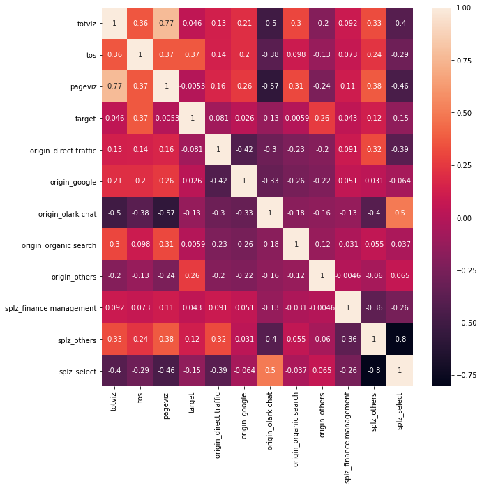

```python
plt.figure(figsize=(10,10))
sns.heatmap(mf.corr(), annot=True)
plt.show()
```

```python
mf.corr().target.abs().sort_values(ascending= False)
```

```
target                     1.000000
tos                        0.365876
origin_others              0.260910
splz_select                0.154025
origin_olark chat          0.129459
splz_others                0.121951
origin_direct traffic      0.080682
totviz                     0.045568
splz_finance management    0.043308
origin_google              0.026286
origin_organic search      0.005879
pageviz                    0.005289
Name: target, dtype: float64
```

```python
final_features= mf.corr().target.abs().sort_values(ascending= False).index.tolist()
```

```python
final_features
```

```
['target',
 'tos',
 'origin_others',
 'splz_select',
 'origin_olark chat',
 'splz_others',
 'origin_direct traffic',
 'totviz',
 'splz_finance management',
 'origin_google',
 'origin_organic search',
 'pageviz']
```

# 10.6 Training the Model

- We will use the standard python library sci-kit learn also called `sklearn` to build logistic regression model
- We shall instantiate differrent modules and submodule of the module to build the logistic regresion model and examine it's effectiveness

[figure not shown]

```python
mf.isnull().sum()[mf.isnull().sum()> 0]
```

```
Series([], dtype: int64)
```

**2 Feature Model**

- Just to keep things simple
- You can add as many dependent variables you like

```python
set1= ['tos','totviz']
```

```python
X= mf[set1]
y= mf.target
```

## 10.6.1 Train Test Split

- train data set: Train the ML model on this portion of the data
- test data set: Blind data set to test efficiency of ML model thus developed

```python
from sklearn.model_selection import train_test_split
X_train, X_test, y_train, y_test = train_test_split(X, y,test_size=0.25, random_state=42)
```

## 10.6.2 Fitting a Model

```python
# import the class
from sklearn.linear_model import LogisticRegression

# instantiate the model (using the default parameters)
logreg = LogisticRegression()
# fit the model with data
logreg.fit(X_train,y_train)
#
y_hat=logreg.predict(X_test)
```

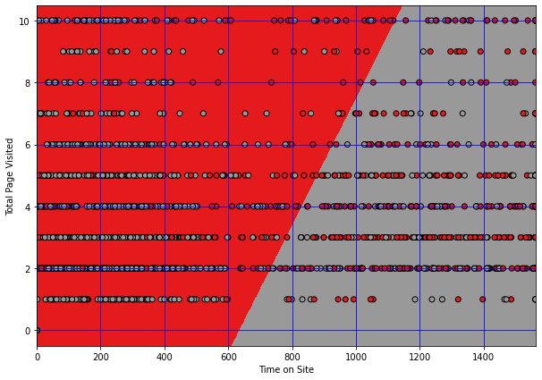

```python
# Create Ranges of Values
x_min, x_max = X_test.iloc[:, 0].min() - .5, X_test.iloc[:, 0].max() + .5
y_min, y_max = X_test.iloc[:, 1].min() - .5, X_test.iloc[:, 1].max() + .5

# Create Meshgrid for above range and
h = .02  # step size in the mesh
xx, yy = np.meshgrid(np.arange(x_min, x_max, h), np.arange(y_min, y_max, h))
Z = logreg.predict(np.c_[xx.ravel(), yy.ravel()])
Z = Z.reshape(xx.shape)
plt.figure(1, figsize=(10,7))
plt.pcolormesh(xx, yy, Z, cmap=plt.cm.Set1)

# Plot also the X_test points
plt.scatter(X_test.iloc[:, 0], X_test.iloc[:, 1], c=y_test, edgecolors='k', cmap=plt.cm.Set1_r)
plt.xlabel('Time on Site')
plt.ylabel('Total Page Visited')

plt.xlim(xx.min(), xx.max())
plt.ylim(yy.min(), yy.max())
plt.xticks()
plt.yticks()
plt.grid(color='blue')
plt.show()
```

**Note:-**

Color Scheme Reversed

- Correctly Classified:
  - Grey on Red
  - Red on Grey
- Incorrectly Classified:
  - Red on Red
  - Grey on Grey

  Watch Out:- Color scheme reversed

# 10.7 Model Evaluation

Classification Models are evaluated with the help of Quality Metrics and not through visual inspection

**Multivariate Model**

The 2 feature model was built mostly for visualization.

Now using the same formulation we shall build a model with 5 features with the highest correlation

```python
# Top 5 features with highest correlation
set2= final_features[1:6]
# creating X and y
X= mf[set2]
y= mf.target
# Train Test split- using pre-loaded modules
X_train, X_test, y_train, y_test = train_test_split(X, y,test_size=0.25, random_state=42)
logreg = LogisticRegression()
# fit the model with data
logreg.fit(X_train,y_train)
#
y_hat=logreg.predict(X_test)
```

```python
set2
```

```
['tos', 'origin_others', 'splz_select', 'origin_olark chat', 'splz_others']
```

## 10.7.1 Model Parameters

```python
logreg.coef_
```

```
array([[ 1.95304724e-03,  2.89142383e+00, -8.01994497e-01,
         1.07904692e+00, -2.13862799e-02]])
```

```python
logreg.intercept_
```

```
array([-1.65510334])
```

```python
logreg.predict_proba(X_test)
```

```
array([[0.76186569, 0.23813431],
       [0.4655817 , 0.5344183 ],
       [0.92079454, 0.07920546],
       ...,
       [0.3142452 , 0.6857548 ],
       [0.37360491, 0.62639509],
       [0.81788118, 0.18211882]])
```

```python
0.76186569+ 0.23813431
```

```
1.0
```

## 10.7.2 Confusion Matrix

A confusion matrix is a table that is used to evaluate the performance of a classification model. You can also visualize the performance of an algorithm. The fundamental of a confusion matrix is the number of correct and incorrect predictions are summed up class-wise

```python
from sklearn import metrics
cnf_matrix = metrics.confusion_matrix(y_test, y_hat)
cnf_matrix
```

```
array([[1190,  214],
       [ 339,  567]])
```

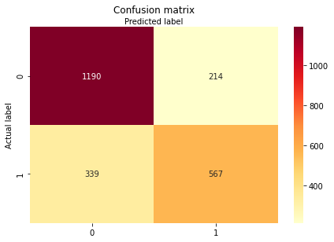

```python
class_names=[1,0] # name  of classes
fig, ax = plt.subplots()
tick_marks = np.arange(len(class_names))
plt.xticks(tick_marks, class_names)
plt.yticks(tick_marks, class_names)
# create heatmap
sns.heatmap(pd.DataFrame(cnf_matrix), annot=True, cmap="YlOrRd" ,fmt='g')
ax.xaxis.set_label_position("top")
plt.tight_layout()
plt.title('Confusion matrix', y=1.1)
plt.ylabel('Actual label')
plt.xlabel('Predicted label')
```

## 10.7.3 Precision & Recall

```python
print("Accuracy:",metrics.accuracy_score(y_test, y_hat))
print("Precision:",metrics.precision_score(y_test, y_hat))
print("Recall:",metrics.recall_score(y_test, y_hat))
```

```
Accuracy: 0.7606060606060606
Precision: 0.7259923175416133
Recall: 0.6258278145695364
```

[figure not shown]

## 10.7.3 Receiver Operating Characteristic(ROC)

Receiver Operating Characteristic(ROC) curve is a plot of the true positive rate against the false positive rate. It shows the tradeoff between sensitivity and specificity

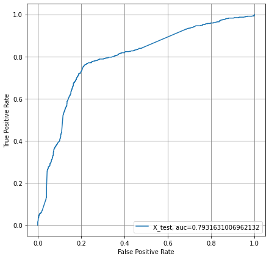

```python
y_pred_proba = logreg.predict_proba(X_test)[::,1]
fpr, tpr, _ = metrics.roc_curve(y_test,  y_pred_proba)
auc = metrics.roc_auc_score(y_test, y_pred_proba)
plt.figure(figsize=(7,7))
plt.plot(fpr,tpr,label="X_test, auc="+str(auc))
plt.legend(loc=4)
plt.grid(color='gray')
plt.xlabel('False Positive Rate')
plt.ylabel('True Positive Rate')
plt.show()
```

# 10.8 Important Concepts at a High Level

## 10.8.1 Overfitting versus Underfitting

[figure not shown]

## 10.8.2 Bias Variance Tradeoff

[figure not shown]

## 10.8.3 Cross-Validation

[figure not shown]

- K= n,5,10 are popular

## 10.8.4 Leakage

- Data leakage (or leakage) happens when your training data contains information about the target, but similar data will not be available when the model is used for prediction.
- This leads to high performance on the training set (and possibly even the validation data), but the model will perform poorly in production.
- To prevent this type of data leakage, any variable updated (or created) after the target value is realized should be excluded.

[figure not shown]